# RSV_analysis

## Beta Diversity

Beta Diversity aims to analyze feature dissimilarity between each pair of samples and utilize distance analysis, like Bray-Curtis or UniFrac. Quantitivate methods, like Bray-Curtis or weighted UniFrac, look at abundance of features in determining distances whereas Qualitative measures, like unweighted uniFrac or binary Jaccard, only look at presence or absence of features. PERMANOVA is used to determine clustering between groups.These are then visualized via PCA or PCoA

### HeatMap

Visualize the Bray-curtis dissimilarity (as two samples share fewer taxa, the number increases 0 for exact same composition, 1 for no shared genera) results.

```r
zp_scale <- zp_rel_abund %>%
    otu_table() %>%
    t() %>%
    scale() %>%
    t() %>%
    otu_table(taxa_are_rows = TRUE)

zpscale <- zp_rel_abund

otu_table(zpscale) <- zp_scale

p <- plot_heatmap(zpscale, method = "NMDS", distance = "bray",
             sample.label = "state", sample.order = "state")
axis_color <- ifelse(p$scales$scales[[1]]$labels == "RSV+", "red", "blue")
p <- p + theme(axis.text.x = element_text(angle = 90, hjust = 1, size = 10, colour = axis_color), plot.margin = unit(c(1,1,1,1),"cm"))

ggsave("Plots/point1/heatmap.jpeg")
```

### PCoA

```r
#Atchinson Distance PCoA
clr_dist_matrix <- phyloseq::distance(zp_rel_abund, method = "euclidean")
eucDis <- ordinate(zp_rel_abund, method = "PCoA", distance = clr_dist_matrix )
PCoA_Atchison_plot <- plot_ordination(zp_rel_abund, eucDis, color = "state")

ggsave("Plots/point1/PCoA_Atchinson.jpeg")

#Bray-Curtis Distance PCoA
pcoa <- ordinate(zp_rel_abund, method = "PCoA", distance = "bray", weighted = TRUE)

PCoA_Bray_plot <- plot_ordination(zp_rel_abund, pcoa, color = "state") +
    scale_color_hue(l=45)

ggsave("Plots/point1/PCoA_Bray.jpeg")
```

### NMDS

```r
zprime.ord <- ordinate(zp_rel_abund, "NMDS", "bray")
```

```
## *** No convergence -- monoMDS stopping criteria:
##     20: stress ratio > sratmax
```

```r
NMDS_plot <- plot_ordination(zp_rel_abund, zprime.ord, type="samples", color="state") +
    #geom_point(size=3) +
    scale_color_hue(l=45)


ggsave("Plots/point1/NMDS.jpeg")
```

### Create one Bray-Curtis Figure

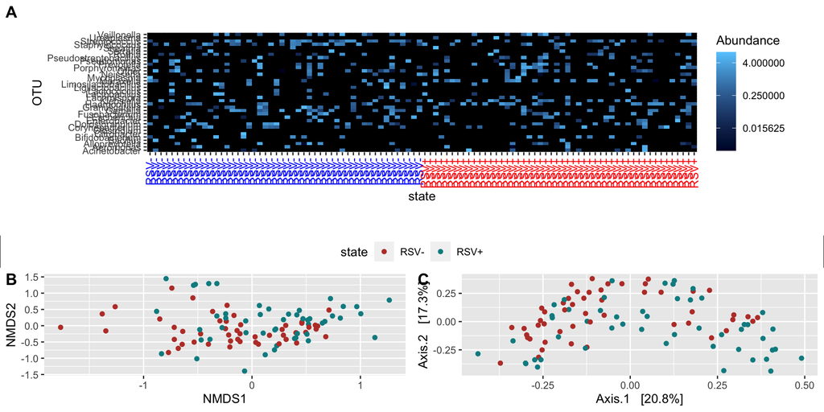

```r
brayCurtisFigure <- ggarrange(p,
                              ggarrange(NMDS_plot, PCoA_Bray_plot,
                                        ncol = 2, labels = c("B", "C"),
                                        common.legend = TRUE),
                    labels = c("A"),nrow = 2, heights = c(2,1.5))+
    bgcolor("white")
brayCurtisFigure
```

```r
ggsave("Plots/point1/BrayCurtisFigure.jpeg")
```

## Differential Abundance Testing

### Wilcoxon-rank sum to determine significant difference between any specific genus

Perform a non-parametric Wilcoxon rank-sum test where the null hypothesis is equal medians between states.

```r
wilcox_test <- list()

zp_pos <- subset_samples(zp_rel_abund, state == "RSV+")
zp_neg <- subset_samples(zp_rel_abund, state =="RSV-")

zp_pos_otu <- otu_table(zp_pos) %>%
  data.frame() %>%
  t() %>%
  as.data.frame()

zp_neg_otu<- otu_table(zp_neg)%>%
  data.frame() %>%
  t() %>%
  as.data.frame()

for(genus in colnames(zp_pos_otu)){
    wilcox_test[[genus]] <- round(wilcox.test(zp_pos_otu[[genus]], zp_neg_otu[[genus]])$p.value, 4)
}

wilcox_test <- as.data.frame(wilcox_test, row.names = "RSV_state") %>%
    t()

wilcox_test <- wilcox_test %>%
   as.data.frame() %>%
   mutate(BH_FDR_state = p.adjust(RSV_state, "BH"))

print(wilcox_test)
```

```
##                       RSV_state BH_FDR_state
## Acinetobacter            0.8848    0.9684000
## Aeromonas                0.4474    0.8375040
## Alloprevotella           0.8289    0.9684000
## Bacillus                 0.7470    0.9684000
## Bifidobacterium          0.8889    0.9684000
## Citrobacter              0.9733    0.9785000
## Clostridium              0.9785    0.9785000
## Corynebacterium          0.8713    0.9684000
## Dolosigranulum           0.2674    0.7045714
## Enterobacter             0.1237    0.4453200
## Escherichia              0.1168    0.4453200
## Fusobacterium            0.2740    0.7045714
## Gemella                  0.0197    0.2364000
## Granulicatella           0.0803    0.4453200
## Haemophilus              0.0589    0.4240800
## Klebsiella               0.3928    0.8375040
## Lacrimispora             0.5646    0.8375040
## Lactobacillus            0.9146    0.9684000
## Lactococcus              0.5191    0.8375040
## Ligilactobacillus        0.1415    0.4630909
## Limosilactobacillus      0.5816    0.8375040
## Moraxella                0.0058    0.2088000
## Mycoplasma               0.4263    0.8375040
## Neisseria                0.5084    0.8375040
## Other                    0.3574    0.8375040
## Porphyromonas            0.1097    0.4453200
## Prevotella               0.5508    0.8375040
## Pseudomonas              0.7071    0.9684000
## Pseudostreptobacillus    0.8767    0.9684000
## Rothia                   0.2680    0.7045714
## Serratia                 0.4860    0.8375040
## Sneathia                 0.5468    0.8375040
## Staphylococcus           0.0181    0.2364000
## Streptococcus            0.0515    0.4240800
## Ureaplasma               0.7931    0.9684000
## Veillonella              0.0985    0.4453200
```

#### Visulaizing Significantly Significant Abundance Grouped by RSV state

Allows visualization of each microbe that has a wilcoxon rankn sum p value <0.06.

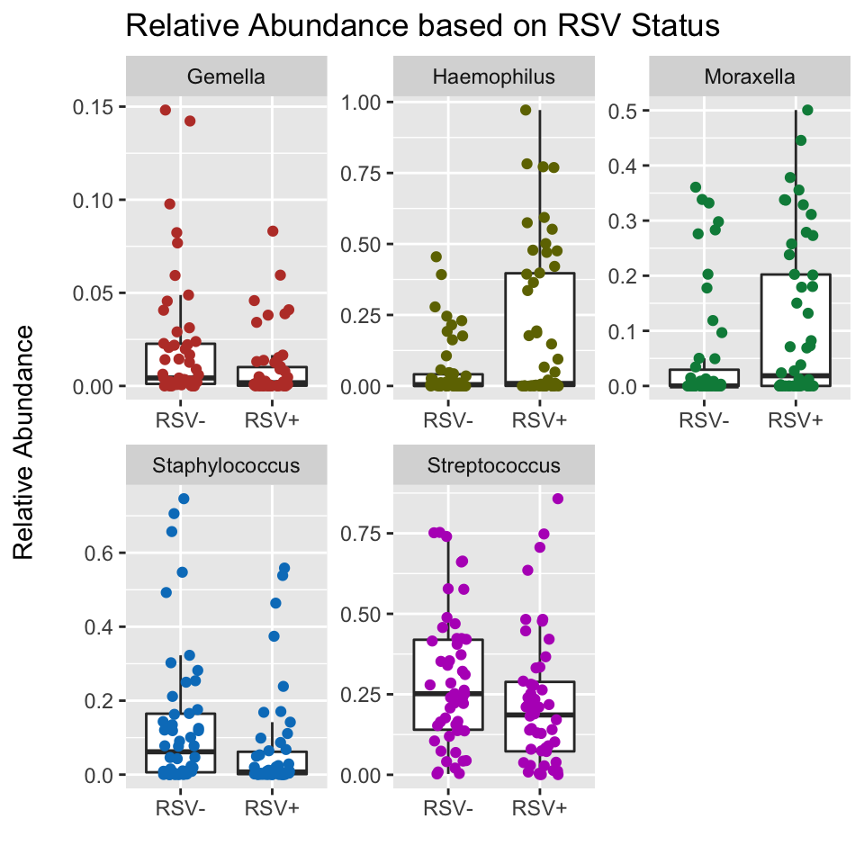

```r
significant_taxa <-  wilcox_test %>%
    as.data.frame() %>%
    filter(RSV_state < 0.06)

if(length(significant_taxa$RSV_state) != 0){

print(psmelt(zp_rel_abund) %>%
  filter(genus %in% row.names(significant_taxa)) %>%
  ggplot(data = ., aes(x = state, y = Abundance)) +
  geom_boxplot(outlier.shape  = NA) +
  geom_jitter(aes(color = genus), height = 0, width = .2) +
  labs(title = "Relative Abundance based on RSV Status", x = "", y = "Relative Abundance\n") +
  facet_wrap(~ OTU, scales = "free") +
  theme(legend.position = "none") +
  scale_color_hue(l=45))


ggsave("Plots/point1/wilcox_test_sig_state.jpeg", dpi = 300, width = 5, height = 4)

}else{
    print("No signifiant taxa via wilcoxon test for RSV status.")
}
```